# Part II - PISA2012 Student Scores in Maths, Science, Reading and Other Features Correlating To Them

## Dataset Overview

The dataset consists of more than 400,000 entries and over 600 features of interest. I chose 27 of these features and focused on plausible values 1 for each subject: science, mathematics and reading. Focusing on the plausible values as student performance indicators, I cross examined them with gender of students, age they started learning, and wealth tendency.

```python
# import all packages and set plots to be embedded inline
import numpy as np
import pandas as pd
import matplotlib.pyplot as plt
import seaborn as sb

%matplotlib inline

# suppress warnings from final output
import warnings
warnings.simplefilter("ignore")
```

```python
# load in the dataset into a pandas dataframe


import pickle


with open("saved_datasets.pkl","rb+") as pkl:
    df_OOS, df_student = pickle.load(pkl)
```

> Note that the above cells have been set as "Skip"-type slides. That means that when the notebook is rendered as http slides, those cells won't show up.

## Scores Distribution

The distribution of scores was normally distributed with no significant skewness. This means that the mean and median of the scores are equal, with averages of scores at: Maths 485.93, Science 484.69, Reading 479.67.

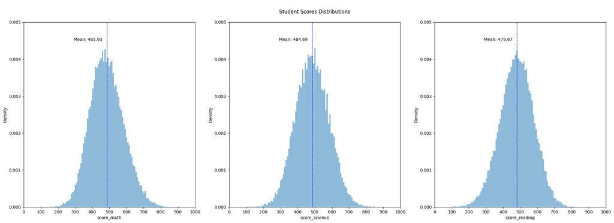

```python
plt.figure(1, figsize=(25,8));
plt.grid(visible = True);

cols = ['score_math','score_science','score_reading']
for i in range(1,4):
    plt.subplot(1,3,i);
    if i == 2:
        plt.title('\nStudent Scores Distributions\n')
    plt.ylim(top= 0.005);
    plt.xlim(right= 1000);
    plt.ylabel('Density');
    plt.xlabel(cols[i-1]);
    plt.xticks(range(0,1100,100));

    plt.hist(data=df_student, x= cols[i-1], density = True, bins=100, alpha= 0.5 );
    plt.axvline(df_student[cols[i-1]].mean(), color='blue', linestyle='dashed', linewidth=1);
    plt.text(df_student[cols[i-1]].mean()*0.6, plt.ylim()[1]*0.9, f'Mean: {df_student[cols[i-1]].mean():.2f}');
```

## Student Gender vs Scores

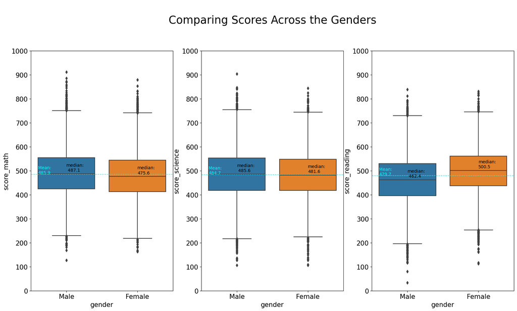

```python
plt.rc('axes', titlesize=25)        # Controls Axes Title
plt.rc('axes', labelsize=15)        # Controls Axes Labels
plt.rc('xtick', labelsize=15)       # Controls x Tick Labels
plt.rc('ytick', labelsize=15)       # Controls y Tick Labels
plt.rc('legend', fontsize=15)       # Controls Legend Font
plt.rc('figure', titlesize=15)      # Controls Figure Title

plt.figure(2, figsize=(20,10));
plt.grid(visible = True);
cols = ['score_math','score_science','score_reading']
for i in range(1,4):
    plt.subplot(1,3,i);
    if i == 2:
        plt.title('\n Comparing Scores Across the Genders \n \n')
    plt.ylim(0,1000)
    plt.yticks(range(0,1100,100))
    box = sb.boxplot(data=df_student, x=df_student.gender,y= cols[i-1]);
    plt.axhline(df_student[cols[i-1]].mean(), color='cyan', linestyle='dashed', linewidth=1);
    plt.text(-0.4,df_student[cols[i-1]].mean(), f'Mean: \n{df_student[cols[i-1]].mean():.1f}', color="cyan");

    med_f = df_student.groupby('gender').get_group("Female")[cols[i-1]].median()
    med_m = df_student.groupby('gender').get_group("Male")[cols[i-1]].median()
    box.annotate(f"median:\n {med_m:.1f}", xy = (0, med_m+10 ))
    box.annotate(f"median:\n{med_f:.1f}", xy = (1, med_f+10 ))
plt.show();
```

## Student Age Started Learning vs Scores

The most prominent effect on scores was the age the student atarted learning. In this feature, there was a clear inversely proportional relationship with the scores: the later the student begins learning in their lifetime, the lower the scores tend to be.

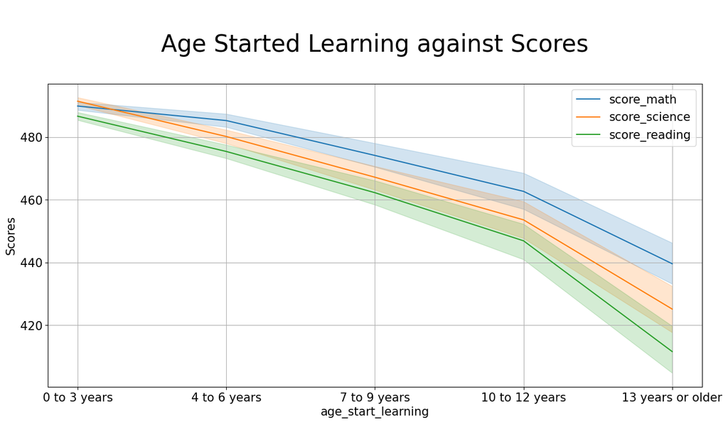

```python
order = ['0 to 3 years', '4 to 6 years', '7 to 9 years', '10 to 12 years', '13 years or older']
df_student.age_start_learning = pd.Categorical(df_student.age_start_learning, categories=order, ordered=True)

plt.rc('axes', titlesize=30)        # Controls Axes Title
plt.rc('axes', labelsize=15)        # Controls Axes Labels
plt.rc('xtick', labelsize=15)       # Controls x Tick Labels
plt.rc('ytick', labelsize=15)       # Controls y Tick Labels
plt.rc('legend', fontsize=15)       # Controls Legend Font
plt.rc('figure', titlesize=15)      # Controls Figure Title

plt.figure(2, figsize=(15,7));
plt.grid(visible = True);

cols = ['score_math','score_science','score_reading']
plt.title('\n Age Started Learning against Scores \n')

sb.lineplot(data=df_student, x=df_student.age_start_learning,y= cols[0], label= cols[0], legend="full");
sb.lineplot(data=df_student, x=df_student.age_start_learning,y= cols[1], label= cols[1], legend="full");
sb.lineplot(data=df_student, x=df_student.age_start_learning,y= cols[2], label= cols[2], legend="full");
plt.ylabel('Scores')
plt.show()
```

## Student Age Started Learning vs Wealth

Now that we have seen a clear relation between age and score, I wanted to see what other features could relate to age start learning factor. In wealth tendency feature, there is a visible decline in wealth tendency with students who started at a later age of their lifetime. This concludes that students who begin learning at an earlier stage of their lifetime have better wealth (~ 0) tendency than those who started at a later stage (< 0).

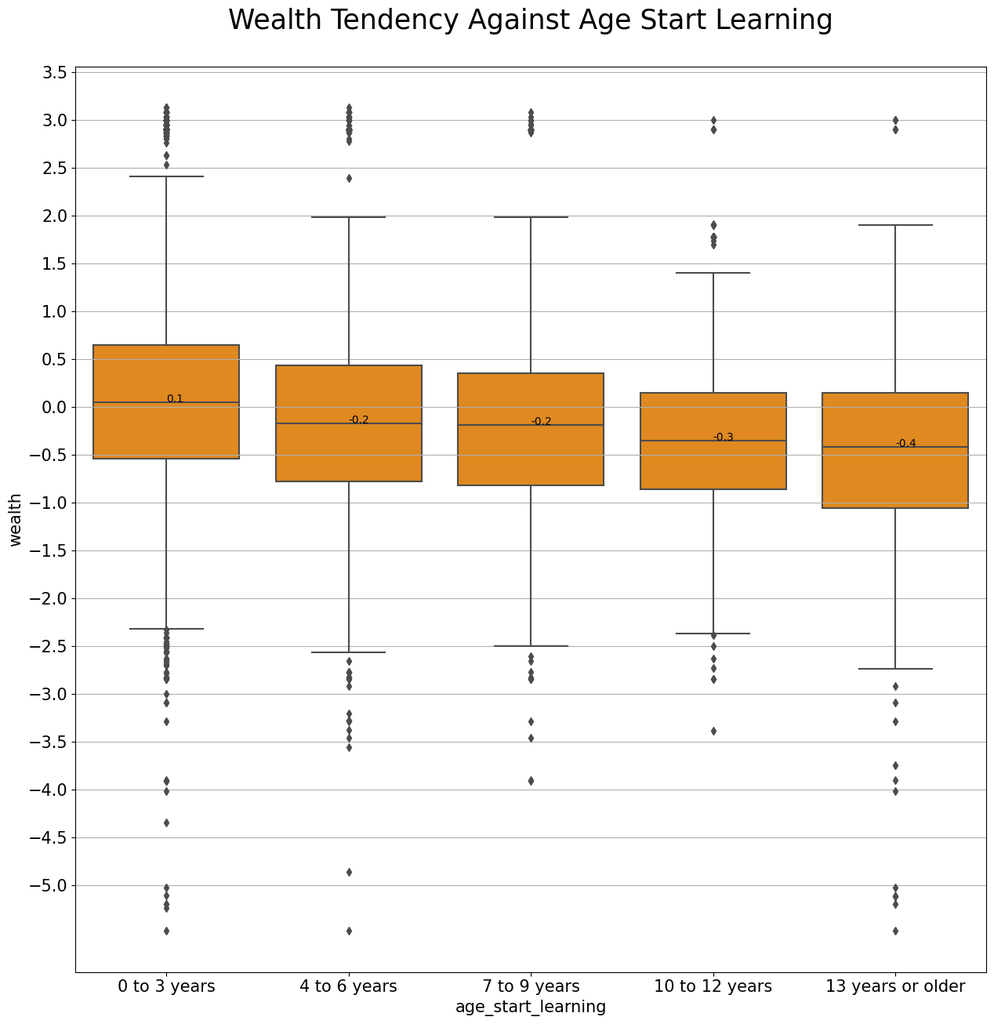

```python
plt.rc('axes', titlesize=25)        # Controls Axes Title
plt.rc('axes', labelsize=15)        # Controls Axes Labels
plt.rc('xtick', labelsize=15)       # Controls x Tick Labels
plt.rc('ytick', labelsize=15)       # Controls y Tick Labels
plt.rc('legend', fontsize=15)       # Controls Legend Font
plt.rc('figure', titlesize=15)      # Controls Figure Title

plt.figure(figsize=(15,15))
plt.yticks([0.5*x for x in range(-10,10,1)])
plt.grid(visible = True);
plt.title('Wealth Tendency Against Age Start Learning\n')
box = sb.boxplot(y= df_student.wealth, x= df_student.age_start_learning, color="darkorange")

for i,j in enumerate(order):
    med_m = df_student.groupby('age_start_learning').get_group(j)['wealth'].median()
    box.annotate(f"{med_m:.1f}", xy = (i, med_m ))
plt.show()
```

> **Generate Slideshow**: Once you're ready to generate your slideshow, use the `jupyter nbconvert` command to generate the HTML slide show. . From the terminal or command line, use the following expression.

```python
!jupyter nbconvert Part_II_slide_deck.ipynb --to slides --post serve --no-input --no-prompt
```

[output not shown]